# Housing Price Prediction - Boulder City

##### **Generalizibility**

We want to be sure our model is generalizing well. If our model is generalizable, we can confidently say the model will predict accurately across different groups, like houses and neighborhoods. To test this we run a k-fold cross validation test, where k = 100. This process splits our data set into 100 groups and measures the model’s goodness of fit across all 100 folds, thus quantifying it’s generalizability. The non-normal distribution of model errors in figure 5 indicate that the model may not be very generalizable. This is important to acknowledge moving forward. Table 3 gives the results of the test set of fold #71. We are able to see the R<sup>2</sup> is higher than that of the entire model, and the MAE is pretty low at 12.9%, however this is just the result of one fold, and the histogram depicts a more accurate representation of how our model is performing.

```r
#Test Generalizability
fitControl <- trainControl(method = "cv", number = 100)
set.seed(825)

reg.cv <-
  train(LNprice ~ MedRent+ HouseAge+ PctMarried+BelPov100+wildfire.nn+geohazard.nn
        +LNlakes.nn+floodzone.nn+Ag.nn+Business.nn+Industrial.nn+NumTrailHeads+bsmtSF+HeatingDscr+TotalBach+
          MedHHInc+TravelTime+nbrBedRoom+qualityCodeDscr+
          TotalFinishedSF+designCodeDscr, data = st_drop_geometry(knownSales),
        method = "lm", trControl = fitControl, na.action = na.pass)

reg.cv$resample[]



reg.cv.rs.min <- reg.cv$resample[71,]
```

```r
reg.cv.rs.min %>%
  gather(Variable, Value) %>%
  group_by(Variable) %>%
  spread(Variable, Value) %>%
  kable(caption = "Table 3: Regression Results of One Test Set") %>%
  kable_classic(full_width = F, html_font = "Helvetica")
```

Table 3: Regression Results of One Test Set

| MAE | Resample | RMSE | Rsquared |
| --- | --- | --- | --- |
| 0.129555041234495 | Fold071 | 0.168399197303377 | 0.886183902533437 |

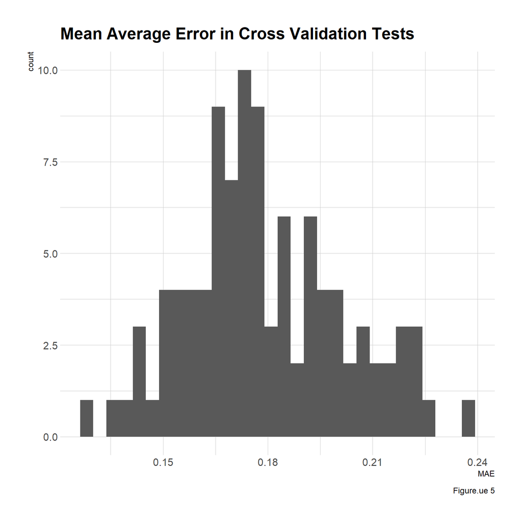

```r
ggplot(reg.cv$resample, aes(x=MAE)) +
  geom_histogram() +
  labs(title = "Mean Average Error in Cross Validation Tests",
       caption = "Figure.ue 5") +
  theme_ipsum_rc()
```

##### **Spatial Clustering of Errors**

In this step we check to see if the residuals are clustered in space. Figure 6 plots our errors in space, which appear to be randomly distributed across census tracts, which may suggest that low generalizability is potentially unrelated to spatial processes. Figure 7 depicts a scatter plot of the spatial lag of price errors. The plot shows that as price decreases, the average spatial lag of the 5 nearest neighbor to that home price increases.

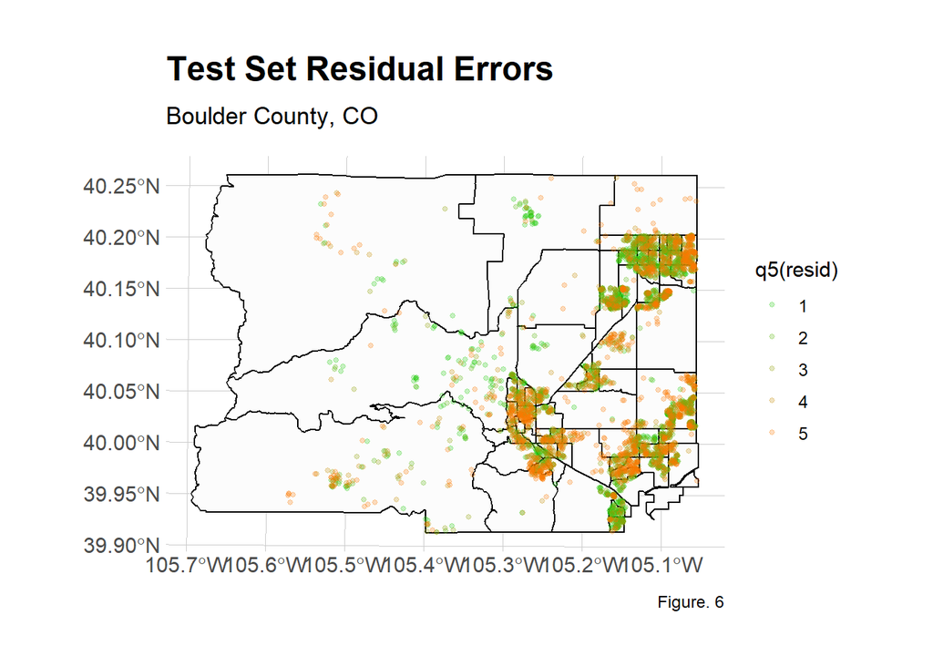

```r
#Map of test set residuals
library(modelr)

boulder.test$resid <-
  boulder.test %>%
  as_data_frame() %>%
  add_residuals(., reg.training, var = "resid") %>%
  dplyr::select(resid) %>%
  pull(resid)

  ggplot() +
  geom_sf(data= tracts19, fill = 'grey99', color = 'black')+
    geom_sf(data = boulder.test, aes(colour = q5(resid)), alpha = .25, size = 1) +
    scale_colour_manual(values = palette5) +
   labs(title = "Test Set Residual Errors",
        subtitle = "Boulder County, CO",
        caption = "Figure. 6") +
    theme_ipsum_rc()
```

```r
#Test Spatial Clustering

coords <- st_coordinates(knownSales)
neighborList <- knn2nb(knearneigh(coords, 5)) #5 nearest neighborhoods
spatialWeights <- nb2listw(neighborList, style="W") #not sure what is W here
knownSales$lagPrice <- lag.listw(spatialWeights, knownSales$price)

coords.test <-  st_c(boulder.test)
neighborList.test <- knn2nb(knearneigh(coords.test, 5))
spatialWeights.test <- nb2listw(neighborList.test, style="W")
```

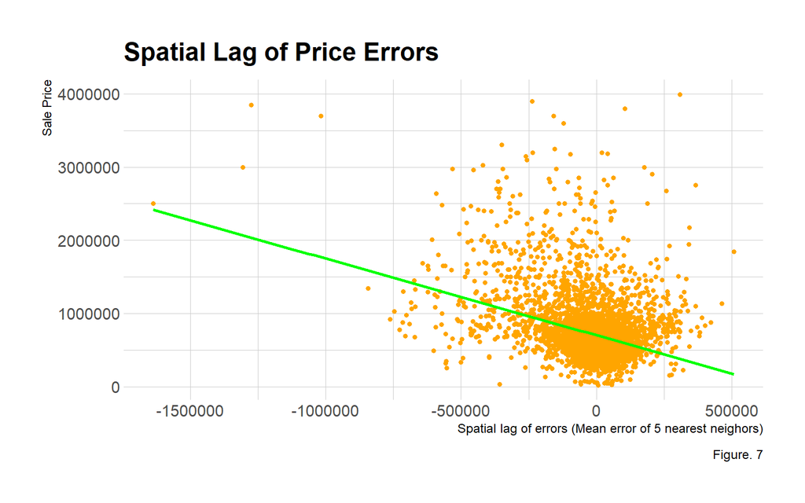

```r
boulder.test %>%
  mutate(lagPriceError = lag.listw(spatialWeights.test, SalePrice.Error)) %>%
  ggplot(aes(lagPriceError, price)) +
  geom_point(size=2, shape=20, color = 'orange') +
  stat_smooth(aes(lagPriceError, price),
             method = "lm", se = FALSE, size = 1, colour="green")+
  labs(x = 'Spatial lag of errors (Mean error of 5 nearest neighors)',
       y = 'Sale Price',
    title = "Spatial Lag of Price Errors",
    caption = "Figure. 7") +
   theme_ipsum_rc()
```

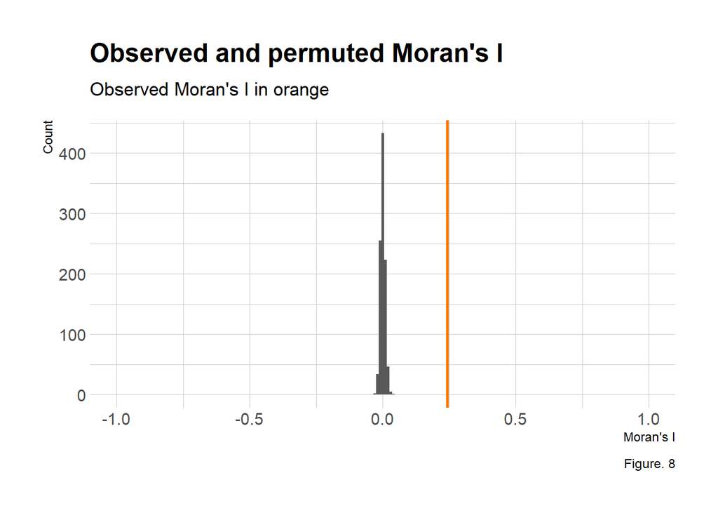

```r
#interpret

moranTest <- moran.mc(boulder.test$SalePrice.Error,
                      spatialWeights.test, nsim = 999)

ggplot(as.data.frame(moranTest$res[c(1:999)]), aes(moranTest$res[c(1:999)])) +
  geom_histogram(binwidth = 0.01) +
  geom_vline(aes(xintercept = moranTest$statistic), colour = "#FA7800",size=1) +
  scale_x_continuous(limits = c(-1, 1)) +
  labs(title="Observed and permuted Moran's I",
       subtitle= "Observed Moran's I in orange",
       x="Moran's I",
       y="Count",
       caption = "Figure. 8") +
  theme_ipsum_rc()
```

```r
#histogram to show frequency of all 999 randomly permutated I
#the observed I is higher than all 999 randomly generated I's suggests
#strong evidence for spatial autocorrelation.
#both spatial lag test and moran's I confirm spatial autocorrelation - this
#suggests that variation in price likely related to the spatial process
#has been omitted from our current model
```

##### **Accounting For Spatial Process**

The next step of this analysis is to incorporate the neighborhood fixed effect into our model to account for the spatial process at the neighborhood scale. In this analysis we use Census tracts as “neighborhoods.” We acknowledge this may not be the most accurate indicator of spatial autocorrelation because we know that census tracts are arbitrarily drawn. Table 4 shows average price and average prediction for each census tract in Boulder County.

```r
#Neighorhood Fixed Effect - accounting for the neighborhood
#Join bytract since we dont have neighborhood data

left_join(
  st_drop_geometry(boulder.test) %>%
    group_by(GEOID) %>%
    summarize(meanPrice = mean(price, na.rm = T)),
  mutate(boulder.test, predict.fe =
           predict(lm(price ~ GEOID, data = boulder.test),
                   boulder.test)) %>%
    st_drop_geometry %>%
    group_by(GEOID) %>%
    summarize(meanPrediction = mean(predict.fe))) %>%
  kable(caption = "Table 4") %>% kable_styling('striped', html_font = 'helvetica')
```

Table 4

| GEOID | meanPrice | meanPrediction |
| --- | --- | --- |
| 08013012101 | 1860198.0 | 1860198.0 |
| 08013012102 | 1221396.8 | 1221396.8 |
| 08013012103 | 1292621.6 | 1292621.6 |
| 08013012104 | 1381165.5 | 1381165.5 |
| 08013012105 | 1240310.0 | 1240310.0 |
| 08013012201 | 1703857.4 | 1703857.4 |
| 08013012202 | 1108435.0 | 1108435.0 |
| 08013012203 | 554912.1 | 554912.1 |
| 08013012204 | 1559528.6 | 1559528.6 |
| 08013012401 | 1339185.2 | 1339185.2 |
| 08013012501 | 783974.1 | 783974.1 |
| 08013012505 | 1405498.1 | 1405498.1 |
| 08013012507 | 682041.2 | 682041.2 |
| 08013012508 | 714300.0 | 714300.0 |
| 08013012509 | 976918.9 | 976918.9 |
| 08013012510 | 1080151.0 | 1080151.0 |
| 08013012511 | 968650.0 | 968650.0 |
| 08013012603 | 991194.4 | 991194.4 |
| 08013012605 | 821000.0 | 821000.0 |
| 08013012607 | 700136.4 | 700136.4 |
| 08013012608 | 669405.4 | 669405.4 |
| 08013012701 | 1008454.5 | 1008454.5 |
| 08013012705 | 686738.5 | 686738.5 |
| 08013012707 | 1405152.9 | 1405152.9 |
| 08013012708 | 918707.1 | 918707.1 |
| 08013012709 | 652489.5 | 652489.5 |
| 08013012710 | 1227701.1 | 1227701.1 |
| 08013012800 | 648859.1 | 648859.1 |
| 08013012903 | 681694.7 | 681694.7 |
| 08013012904 | 613631.7 | 613631.7 |
| 08013012905 | 552564.5 | 552564.5 |
| 08013012907 | 553178.9 | 553178.9 |
| 08013013003 | 785234.7 | 785234.7 |
| 08013013004 | 711674.4 | 711674.4 |
| 08013013005 | 794410.0 | 794410.0 |
| 08013013006 | 757098.8 | 757098.8 |
| 08013013201 | 1000815.0 | 1000815.0 |
| 08013013202 | 1499750.0 | 1499750.0 |
| 08013013205 | 1130811.2 | 1130811.2 |
| 08013013207 | 542164.7 | 542164.7 |
| 08013013208 | 470477.3 | 470477.3 |
| 08013013210 | 375753.1 | 375753.1 |
| 08013013211 | 599515.4 | 599515.4 |
| 08013013212 | 465410.0 | 465410.0 |
| 08013013213 | 708781.6 | 708781.6 |
| 08013013302 | 494697.9 | 494697.9 |
| 08013013305 | 383632.4 | 383632.4 |
| 08013013306 | 377861.0 | 377861.0 |
| 08013013307 | 384068.1 | 384068.1 |
| 08013013308 | 403241.3 | 403241.3 |
| 08013013401 | 407461.2 | 407461.2 |
| 08013013402 | 451327.4 | 451327.4 |
| 08013013503 | 398889.4 | 398889.4 |
| 08013013505 | 373572.7 | 373572.7 |
| 08013013506 | 480748.4 | 480748.4 |
| 08013013507 | 407036.2 | 407036.2 |
| 08013013508 | 510706.3 | 510706.3 |
| 08013013601 | 751512.2 | 751512.2 |
| 08013013602 | 431713.9 | 431713.9 |
| 08013013701 | 986575.6 | 986575.6 |
| 08013013702 | 618076.0 | 618076.0 |
| 08013060600 | 640237.2 | 640237.2 |
| 08013060700 | 725423.0 | 725423.0 |
| 08013060800 | 489477.6 | 489477.6 |
| 08013060900 | 677907.0 | 677907.0 |
| 08013061300 | 778994.8 | 778994.8 |
| 08013061400 | 731447.7 | 731447.7 |

```r
reg.tract <- lm(LNprice ~ ., data = as.data.frame(boulder.training) %>%
                  dplyr::select(LNprice, GEOID, MedRent, HouseAge, PctMarried, BelPov100, wildfire.nn, geohazard.nn,
                                LNlakes.nn, floodzone.nn, Ag.nn, Business.nn, Industrial.nn, NumTrailHeads,
                                bsmtSF, HeatingDscr, TotalBach,
                                MedHHInc, TravelTime, nbrBedRoom, qualityCodeDscr,
                                TotalFinishedSF, designCodeDscr))

summary(reg.tract)
boulder.test.tract <-
  boulder.test %>%
  mutate(Regression = "Neighborhood Effects",
         SalePrice.Predict = exp(predict(reg.tract, boulder.test)),
         SalePrice.Error = SalePrice.Predict - price,
         SalePrice.AbsError = abs(SalePrice.Predict - price),
         SalePrice.APE = (abs(SalePrice.Predict - price)) / SalePrice.Predict)%>%
  filter(price < 4000000)
```

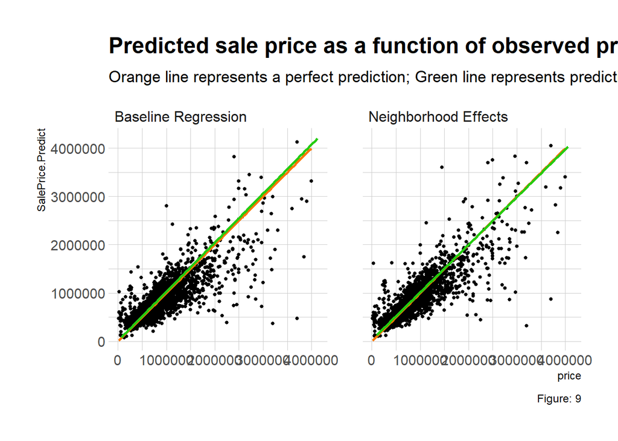

```r
bothRegressions <-
  rbind(
    dplyr::select(boulder.test, starts_with("SalePrice"), price, Regression, GEOID) %>%
      mutate(lagPriceError = lag.listw(spatialWeights.test, SalePrice.Error)),
    dplyr::select(boulder.test.tract, starts_with("SalePrice"), price, Regression, GEOID) %>%
      mutate(lagPriceError = lag.listw(spatialWeights.test, SalePrice.Error)))

bothRegressions %>%
  dplyr::select(SalePrice.Predict,price, Regression) %>%
  ggplot(aes(price, SalePrice.Predict)) +
  geom_point(size = 1) +
  stat_smooth(aes(price, price),
              method = "lm", se = FALSE, size = 1, colour="#FA7800") +
  stat_smooth(aes(SalePrice.Predict, price),
              method = "lm", se = FALSE, size = 1, colour="#25CB10") +
  facet_wrap(~Regression) +
  labs(title="Predicted sale price as a function of observed price",
       subtitle="Orange line represents a perfect prediction; Green line represents prediction",
       caption = "Figure: 9") +
  theme_ipsum_rc()
```

```r
both.reg <- st_drop_geometry(bothRegressions) %>%
  gather(Variable, Value, -Regression, -GEOID) %>%
  filter(Variable == "SalePrice.AbsError" | Variable == "SalePrice.APE") %>%
  group_by(Regression, Variable) %>%
  summarize(meanValue = mean(Value, na.rm = T)) %>%
  spread(Variable, meanValue) %>%
  kable(caption = "Table 5")%>%kable_styling()
both.reg
```

Table 5

| Regression | SalePrice.AbsError | SalePrice.APE |
| --- | --- | --- |
| Baseline Regression | 132076.0 | 0.1804844 |
| Neighborhood Effects | 116602.2 | 0.1558242 |

Figure 10 illustrates clustering of our predicted home prices in and around downtown Boulder, wich follows the same patterns as the known home sale prices. Figure 11 depicts the spatial distribution of our model’s errors. We can see from this map, that the mean average percentage error is highest both where home prices are higher, and also in the large tracts to the west which represent primarily undeveloped mountainous park land. This could be explained by the wide range of home sale prices in these tracts because of the comparative size. Figure 12 further illustrates the varying relationships between MAPE and mean house price by census tract. From this chart, we may be able to say as Mean price by census tract increases, the MAPE by census tract slightly increases as well. With the MAPE being inconsistent across Census tracts and associated average home sale prices, we may say this is further evidence that our model is not as generalizable as it could be.

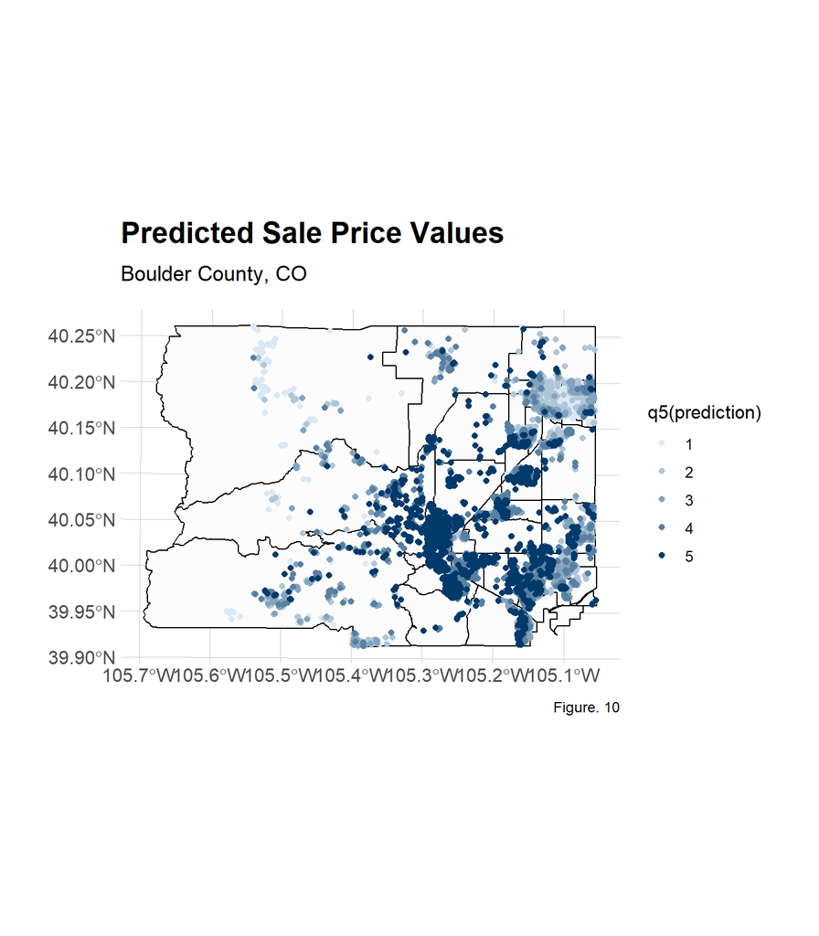

```r
housesPredictions <-
  HouseData %>%
  mutate(prediction = exp(predict(reg.tract, HouseData)),
         team_name = 'HROS')

predictions <- housesPredictions[,c("prediction", "team_name", "toPredict")] %>%
  st_drop_geometry() %>%
  filter(toPredict == 1) %>%
  dplyr::select(-toPredict)

predictplot<- ggplot() +
  geom_sf(data= tracts19, fill = 'grey99', color = 'black')+
  geom_sf(data = housesPredictions, aes(colour = q5(prediction)))+
  scale_colour_manual(values = paletteMap)+
  labs(title = "Predicted Sale Price Values",
       subtitle = "Boulder County, CO",
       caption = 'Figure. 10') +
  mapTheme()+theme_ipsum_rc()

predictplot
```

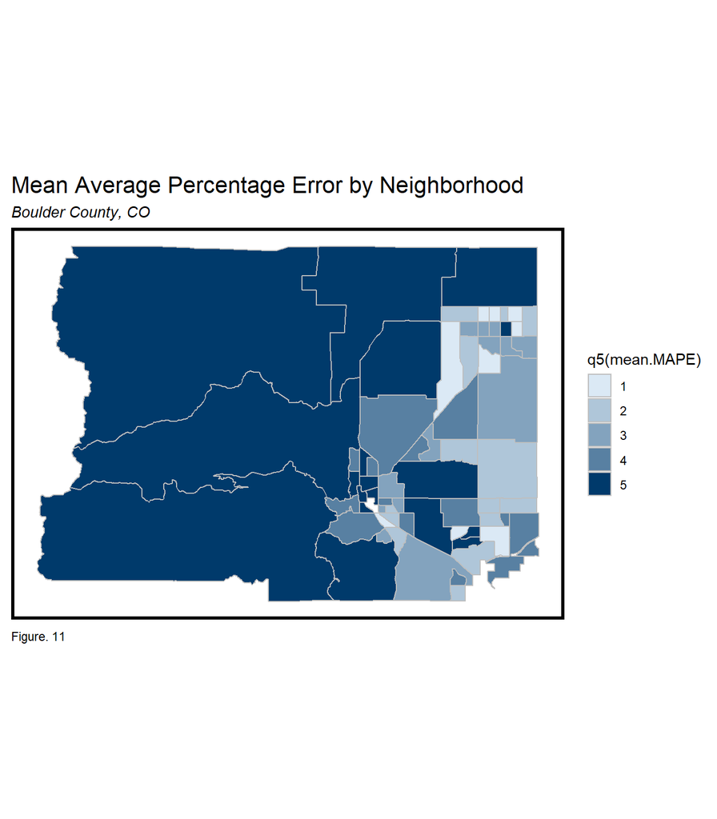

```r
st_drop_geometry(bothRegressions) %>%
  group_by(Regression, GEOID)%>%
  summarise(mean.MAPE = mean(SalePrice.APE, na.rm = T)) %>%
  ungroup() %>%
  left_join(tracts19) %>%
  st_as_sf() %>%
  ggplot() +
  geom_sf(colour = "gray", aes(fill = q5(mean.MAPE))) +
  scale_fill_manual(values = paletteMap) +
  labs(title = "Mean Average Percentage Error by Neighborhood",
       subtitle = "Boulder County, CO",
       caption = "Figure. 11") +
  mapTheme()
```

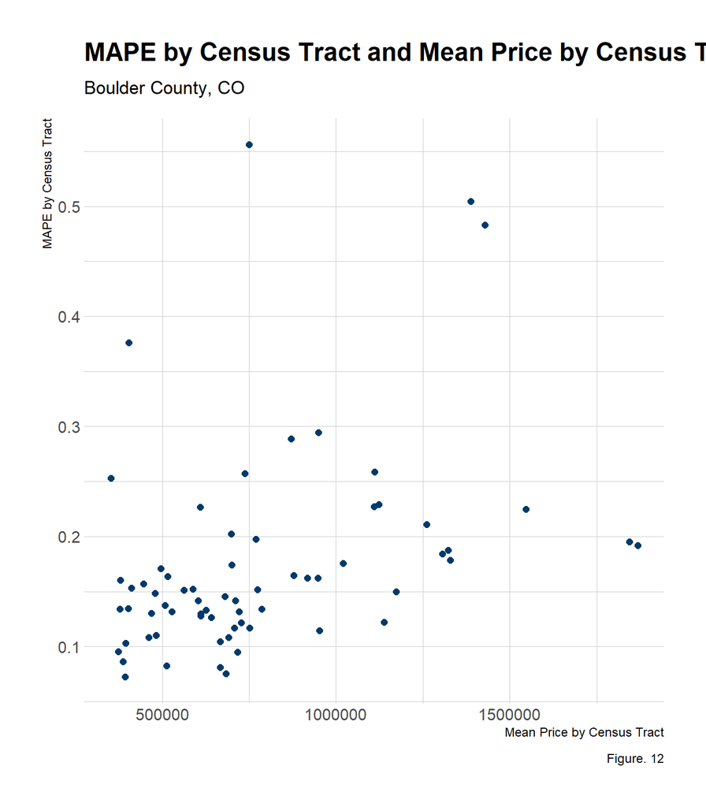

```r
scatter_tracts <-
  boulder.test.tract %>%
  group_by(GEOID) %>%
  dplyr::select(GEOID, SalePrice.APE, SalePrice.Predict)

mean_sca_t <-
  scatter_tracts %>%
  group_by(GEOID) %>%
  summarise_at(vars("SalePrice.APE", "SalePrice.Predict"), mean)

ggplot()+
  geom_point(data = mean_sca_t,
             aes(SalePrice.Predict,SalePrice.APE),
             size = 2,
             color = "#003A6B" )+
  labs(x = 'Mean Price by Census Tract',
       y = 'MAPE by Census Tract',
       title = "MAPE by Census Tract and Mean Price by Census Tract",
       subtitle = "Boulder County, CO",
       caption = "Figure. 12") +
  theme_ipsum_rc()
```

[figure not shown]

```r
tracts19<- tracts19%>%
  mutate(raceContext = ifelse(PctWhite > .8, "At least \n80% White", "At most 20% \nNon-White"),
       incomeContext = ifelse(MedHHInc > 65000, "High Income", "Low Income"))

grid.arrange(ncol = 2,
             ggplot() + geom_sf(data = na.omit(tracts19), aes(fill = raceContext)) +
               scale_fill_manual(values = c("#25CB10", "#FA7800"), name="Race Context") +
               labs(title = "Race Context") +
               mapTheme() + theme(legend.position="bottom"),
             ggplot() + geom_sf(data = na.omit(tracts19), aes(fill = incomeContext)) +
               scale_fill_manual(values = c("#25CB10", "#FA7800"), name="Income Context") +
               labs(title = "Income Context",
                    caption = "Figure. 13") +
               mapTheme() + theme(legend.position="bottom"))
```

```r
st_join(bothRegressions, tracts19) %>%
  group_by(Regression, raceContext) %>%
  summarize(mean.MAPE = scales::percent(mean(SalePrice.APE, na.rm = T))) %>%
  st_drop_geometry() %>%
  spread(raceContext, mean.MAPE) %>%
  kable(caption = "Table 6: Test set MAPE by neighborhood racial context")%>%kable_styling()
```

Table 6: Test set MAPE by neighborhood racial context

[output not shown]

```r
st_join(bothRegressions, tracts19) %>%
  filter(!is.na(incomeContext)) %>%
  group_by(Regression, incomeContext) %>%
  summarize(mean.MAPE = scales::percent(mean(SalePrice.APE, na.rm = T))) %>%
  st_drop_geometry() %>%
  spread(incomeContext, mean.MAPE) %>%
  kable(caption = "Table 7: Test set MAPE by neighborhood income context")%>%kable_styling()
```

Table 7: Test set MAPE by neighborhood income context

| Regression | High Income | Low Income |
| --- | --- | --- |
| Baseline Regression | 18% | 22% |
| Neighborhood Effects | 15% | 18% |

## **V. Discussion & Conclusion**

We have wrangled and included a range of variables from demographic to geographic which have proved to have an impact on home sale price. As predicted the housing costs are higher closer to the Boulder downtown, Lakes, reservoirs and industrial areas but relatively low and have a negative relation to areas closer to wild fire and geo-hazard areas. Given the MAEP is relatively low for both low income and high income group, with low income having slightly higher error. We think that might be due to the bias of the study area, which is a very wealthy county.

Overall, our model is relatively effective at predicting home sale prices, however it does not appear to be generalizable which is a crucial part of making sure our model performs accurately across both space and time. From the results of this analysis, we believe there should be more iterations of this model produced before it is utilized as a business algorithm. There are other models we may use to predict home prices which account for the spatial processes happneing within our dependent variable and our independent predictions, which should be considered in further analysis of building the optimal model for Zillow to use.